# Sample Check Report

Jineta Banerjee

Sage Bionetworks

16 December, 2022

### 0.0.1 Summary

This document contains a simple check for NF-OSI processed RNAseq files. It contains the following:

- A principal component analysis plot with all the samples
- A table with raw counts of housekeeping genes in the samples

NOTE: Two samples 2-009-pdx and WU-536-pdx were found to contain high levels of mouse DNA. So most of the reads in these samples mapped to the mouse genome and not the human genome.

### 0.0.2 Sample identity of files being checked

*Fill in the values for each sample sheet*

- Study : [Predictive Modeling Utilizing a Preclinical NF1-MPNST Platform Suitable for Precision Oncology](https://www.synapse.org/#!Synapse:syn21984813/wiki/602362)
- Samples : PDX, Patient(Pt)
- MultiQC reports : [PDX](https://www.synapse.org/#!Synapse:syn49553414), [PT](https://www.synapse.org/#!Synapse:syn49554818)

### 0.0.3 Principal component analysis:

The plot below visualizes the distribution of samples **without** any normalization or batch correction. Samples are labeled with their specimenIDs (as present in Synapse metadata) for easy identification.

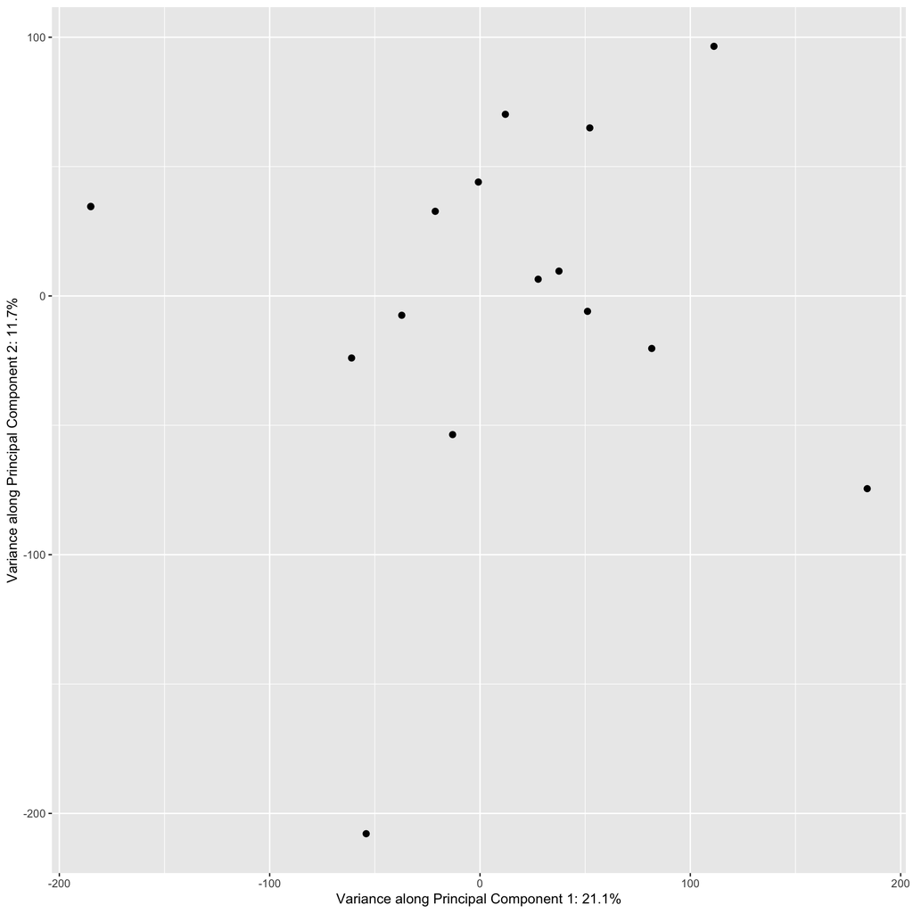

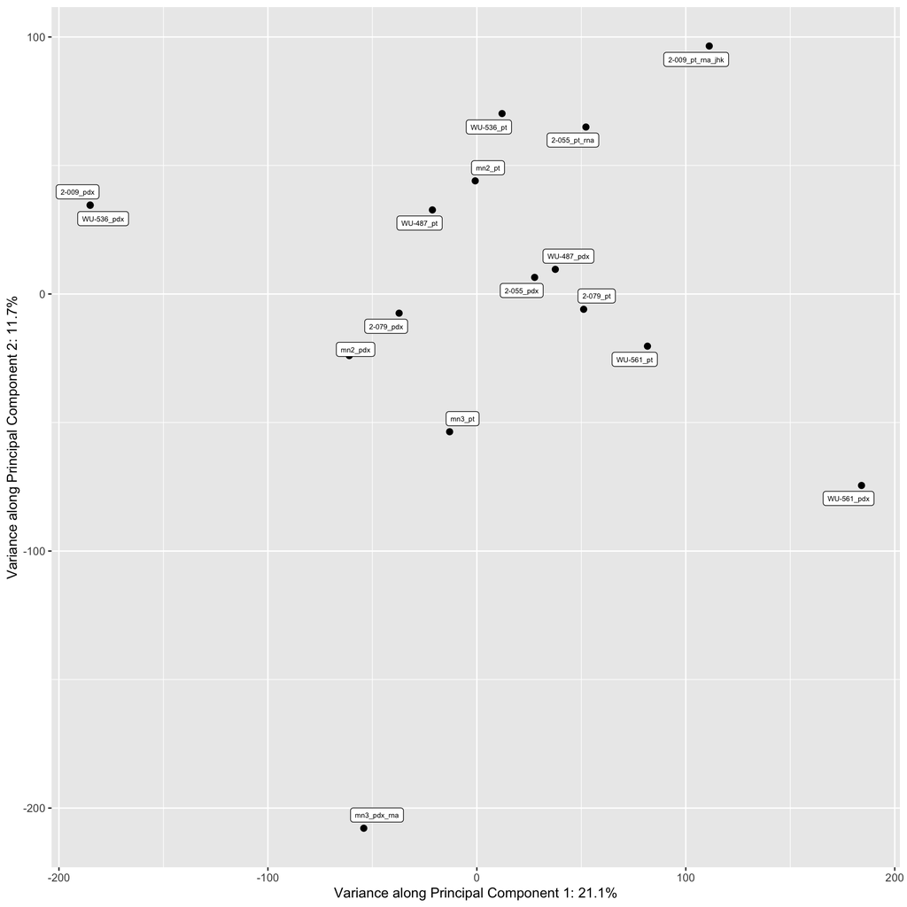

### 0.0.4 Raw counts of few housekeeping genes:

A glance at the raw counts of some housekeeping genes in the samples:

|  | GAPDH | ACTB | SDHA | TFRC | GUSB | TBP | PGK1 |
| --- | --- | --- | --- | --- | --- | --- | --- |
| 2-009_pdx | 13 | 18 | 0 | 1 | 0 | 1 | 5 |
| 2-055_pdx | 9127.995 | 9361.001 | 684.294 | 1159.001 | 434.998 | 115 | 1698 |
| 2-079_pdx | 16721.982 | 6912.001 | 431.041 | 1656.001 | 351 | 98 | 1822.999 |
| WU-487_pdx | 18496.999 | 6546.998 | 365.23 | 4120.002 | 121 | 131.999 | 6440.994 |
| WU-536_pdx | 12 | 50 | 2 | 1 | 0 | 0 | 3 |
| WU-561_pdx | 18546 | 42679.248 | 450.833 | 2470.001 | 940.323 | 238 | 3619.001 |
| mn2_pdx | 13863.998 | 15675 | 572.304 | 905.999 | 324.999 | 121.001 | 2945.999 |
| mn3_pdx_rna | 15538 | 13515.363 | 543.025 | 790.998 | 333 | 158.999 | 4449 |
| 2-009_pt_rna_jhk | 12288.999 | 52381.277 | 1239.504 | 636.999 | 1269.001 | 185.001 | 3355 |
| 2-055_pt_rna | 10708.998 | 40793.665 | 793.248 | 1458.999 | 394.999 | 102 | 2282.001 |

[output cut: 6 more lines]

We observed that sample 2-009-pdx, and WU-536-pdx showed low number of counts in the housekeeping genes. Our review of the [logs of the disambiguation step](https://www.synapse.org/#!Synapse:syn49550727) of the processing pipeline suggests that these two samples contained high level of mouse DNA, i.e. the majority of reads mapped to the mouse genome (GRCm38) and only a minority mapped to the human genome.